# DNA assembly using De Bruijn graphs

Today we will assemble a string of text:

- without fragmenting it, but only varying its level of complexity
- fragmenting it in two different ways

```python
def extract_k_mer(sequence,k):
    k_mer = []
    for i in range(len(sequence)-k+1):
        k_mer.append(sequence[i:k+i])
    return k_mer
```

```python
def de_bruijn_graph(k_mer):
    nodes = set()
    edges = []
    for k in k_mer:
        k1 = k[:-1]
        k2 = k[1:]
        nodes.add(k1)
        nodes.add(k2)
        edges.append((k1,k2))
    return (nodes, edges)
```

Let's start with a simple string.

```python
sq = 'The cipher'

kmers_sq = extract_k_mer(sq, 5)
kmers_sq
```

```
['The c', 'he ci', 'e cip', ' ciph', 'ciphe', 'ipher']
```

```python
G_sq = de_bruijn_graph(kmers_sq)
```

```python
print(G_sq[0])
```

```
{'ciph', 'iphe', ' cip', 'e ci', 'The ', 'pher', 'he c'}
```

```python
print(G_sq[1])
```

```
[('The ', 'he c'), ('he c', 'e ci'), ('e ci', ' cip'), (' cip', 'ciph'), ('ciph', 'iphe'), ('iphe', 'pher')]
```

```python
import networkx as nx
```

```python
g_sq = nx.DiGraph()
g_sq.add_nodes_from(G_sq[0])
g_sq.add_edges_from(G_sq[1])
```

```python
import pylab as plt
```

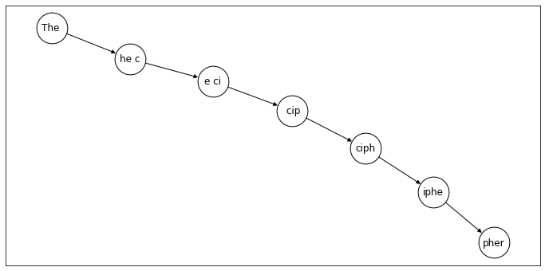

```python
plt.figure(figsize=(12,6))
nx.draw_networkx(g_sq, pos = nx.nx_agraph.graphviz_layout(g_sq), with_labels = True, arrows = True,
                 node_shape = "o", node_size = 1500, node_color = "white", edgecolors = "black")
```

We have an **eulerian path** within a directed and connected graph, if and only if at most 2 nodes are semi-balanced and all other nodes are balanced.

A node is **balanced** if indegree equals outdegree.

A node is **semi-balanced** if indegree differs from outdegree by 1.

```python
dgin_sq = g_sq.in_degree()
dgout_sq = g_sq.out_degree()
print(dgin_sq)
print(dgout_sq)
```

```
[('ciph', 1), ('iphe', 1), (' cip', 1), ('e ci', 1), ('The ', 0), ('pher', 1), ('he c', 1)]
[('ciph', 1), ('iphe', 1), (' cip', 1), ('e ci', 1), ('The ', 1), ('pher', 0), ('he c', 1)]
```

```python
from collections import Counter

bn = []
for i in G_sq[0]:
    bn.append(abs(dgin_sq[i]-dgout_sq[i]))

Counter(bn)
```

```
Counter({0: 5, 1: 2})
```

```python
starting_node = []
for i in dgin_sq:
    if i[1] == 0:
        starting_node.append(i[0])

starting_node
```

```
['The ']
```

```python
eu_path_sq = list(nx.eulerian_path(g_sq))
print(eu_path_sq)
```

```
[('The ', 'he c'), ('he c', 'e ci'), ('e ci', ' cip'), (' cip', 'ciph'), ('ciph', 'iphe'), ('iphe', 'pher')]
```

```python
final_assembly_sq = eu_path_sq[0][0]
for i in range(len(eu_path_sq)):
    final_assembly_sq = final_assembly_sq + eu_path_sq[i][1][-1]

print(final_assembly_sq)
```

```
The cipher
```

Let's consider a more complex string.

```python
m0 = 'The cipher of Caesar is named after Julius Caesar, who used it with the intent of protecting his encrypted messages'
```

```python
kmers_m0 = extract_k_mer(m0,5)

G_m0 = de_bruijn_graph(kmers_m0)
```

```python
g_m0 = nx.DiGraph()
g_m0.add_nodes_from(G_m0[0])
g_m0.add_edges_from(G_m0[1])
```

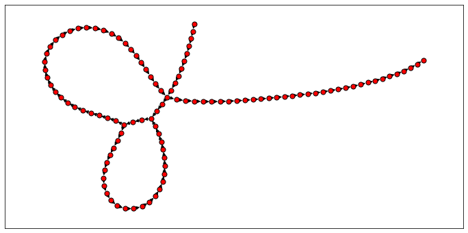

```python
plt.figure(figsize=(12,6))
nx.draw_networkx(g_m0, pos = nx.nx_agraph.graphviz_layout(g_m0), with_labels = False, arrows = True,
                 node_shape = "o", node_size = 50, node_color = "red", edgecolors = "black")
```

```python
dgin_sq = g_m0.in_degree()
dgout_sq = g_m0.out_degree()

bn = []
for i in G_m0[0]:
    bn.append(abs(dgin_sq[i]-dgout_sq[i]))

Counter(bn)
```

```
Counter({0: 103, 1: 4})
```

Let's try to increase the **size of k-mers**.

```python
kmers_m0 = extract_k_mer(m0,8)

G_m0 = de_bruijn_graph(kmers_m0)
```

```python
g_m0 = nx.DiGraph()
g_m0.add_nodes_from(G_m0[0])
g_m0.add_edges_from(G_m0[1])
```

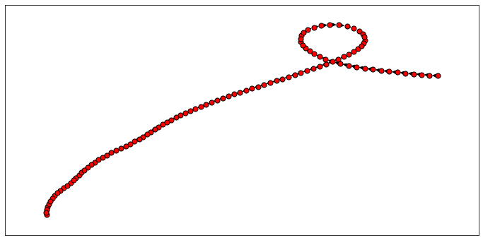

```python
plt.figure(figsize=(12,6))
nx.draw_networkx(g_m0, pos = nx.nx_agraph.graphviz_layout(g_m0), with_labels = False, arrows = True,
                 node_shape = "o", node_size = 50, node_color = "red", edgecolors = "black")
```

```python
subset = []
for i in range(50):
    subset.append(G_m0[1][i][0])
    subset.append(G_m0[1][i][1])
```

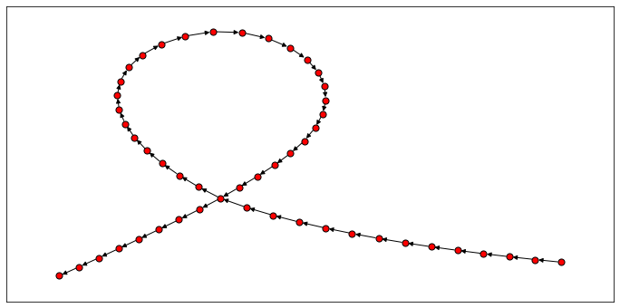

```python
plt.figure(figsize=(12,6))
nx.draw_networkx(g_m0.subgraph(subset), pos = nx.nx_agraph.graphviz_layout(g_m0), with_labels = False, arrows = True,
                 node_shape = "o", node_size = 50, node_color = "red", edgecolors = "black")
```

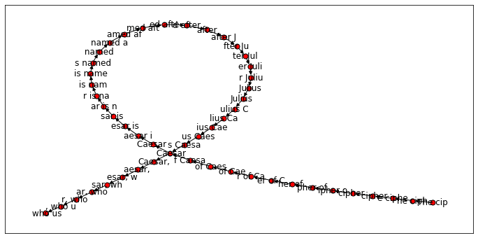

```python
plt.figure(figsize=(12,6))
nx.draw_networkx(g_m0.subgraph(subset), pos = nx.nx_agraph.graphviz_layout(g_m0), with_labels = True, arrows = True,
                 node_shape = "o", node_size = 50, node_color = "red", edgecolors = "black")
```

```python
dgin_sq = g_m0.in_degree()
dgout_sq = g_m0.out_degree()

bn = []
for i in G_m0[0]:
    bn.append(abs(dgin_sq[i]-dgout_sq[i]))

Counter(bn)
```

```
Counter({0: 106, 1: 2})
```

```python
starting_node = []
for i in dgin_sq:
    if i[1] == 0:
        starting_node.append(i[0])

starting_node
```

```
['The cip']
```

```python
eu_path_m0 = list(nx.eulerian_path(g_m0))
eu_path_m0[0]
```

```
('The cip', 'he ciph')
```

```python
final_assembly_m0 = eu_path_m0[0][0]
for i in range(len(eu_path_m0)):
    final_assembly_m0 = final_assembly_m0 + eu_path_m0[i][1][-1]

print(final_assembly_m0)
```

```
The cipher of Caesar is named after Julius Caesar, who used it with the intent of protecting his encrypted messages
```

Let's now simulate a more realistic situation: let's try to reconstruct this string starting from a set of **fragments**.

```python
f1 = 'The cipher of Caesa'
f2 = 'the intent of protecting his'
f3 = 'ting his encrypted messages'
f4 = 'aesar is named after Ju'
f5 = 'aesar, who used it with the int'
f6 = 'after Julius Caesar'
```

```python
ffl = [f1, f2, f3, f4, f5, f6]
kmer_list = []
for i in ffl:
    kmer_list.append(extract_k_mer(i,5))
```

```python
kmer_all = []
for i in kmer_list:
    for j in i:
        kmer_all.append(j)

kmer_unique = set(kmer_all)

print(len(kmer_all))
print(len(kmer_unique))
```

```
123
108
```

```python
G_m1 = de_bruijn_graph(kmer_unique)

g_m1 = nx.DiGraph()
g_m1.add_nodes_from(G_m1[0])
g_m1.add_edges_from(G_m1[1])
```

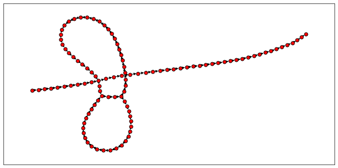

```python
plt.figure(figsize=(12,6))
nx.draw_networkx(g_m1, pos = nx.nx_agraph.graphviz_layout(g_m1), with_labels = False,
                 arrows = True, node_shape = "o", node_size = 50, node_color = "red",
                 edgecolors = "black")
```

```python
dgin_sq = g_m1.in_degree()
dgout_sq = g_m1.out_degree()

bn = []
for i in G_m1[0]:
    bn.append(abs(dgin_sq[i]-dgout_sq[i]))

Counter(bn)
```

```
Counter({0: 103, 1: 4})
```

Let's try to increase the size of the k-mers.

```python
ffl = [f1, f2, f3, f4, f5, f6]
kmer_list = []
for i in ffl:
    kmer_list.append(extract_k_mer(i,8))
```

```python
kmer_all = []
for i in kmer_list:
    for j in i:
        kmer_all.append(j)

kmer_unique = set(kmer_all)
```

```python
G_m1 = de_bruijn_graph(kmer_unique)

g_m1 = nx.DiGraph()
g_m1.add_nodes_from(G_m1[0])
g_m1.add_edges_from(G_m1[1])
```

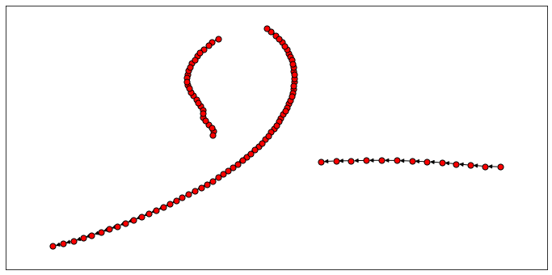

```python
plt.figure(figsize=(12,6))
nx.draw_networkx(g_m1, pos = nx.nx_agraph.graphviz_layout(g_m1), with_labels = False,
                 arrows = True, node_shape = "o", node_size = 50, node_color = "red",
                 edgecolors = "black")
```

Let's now consider a different set of fragments.

```python
ff1 = 'The cipher of Caesar is named after Julius Caesar,'
ff2 = 'Julius Caesar, who used it with the intent of protecting'
ff3 = 'is named after Julius Caesar, who used it'
ff4 = 'with the intent of protecting his encrypted messages'
```

```python
F = [ff1, ff2, ff3, ff4]
kmer_list = []
for i in F:
    kmer_list.append(extract_k_mer(i,8))
```

```python
kmer_all = []
for i in kmer_list:
    for j in i:
        kmer_all.append(j)

kmer_unique = set(kmer_all)
```

```python
G_m2 = de_bruijn_graph(kmer_unique)

g_m2 = nx.DiGraph()
g_m2.add_nodes_from(G_m2[0])
g_m2.add_edges_from(G_m2[1])
```

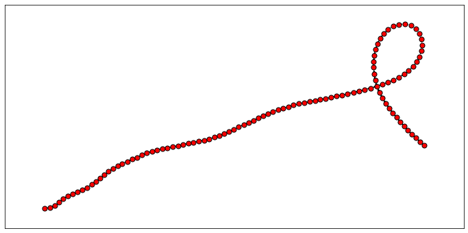

```python
plt.figure(figsize=(12,6))
nx.draw_networkx(g_m2, pos = nx.nx_agraph.graphviz_layout(g_m2), with_labels = False, arrows = True,
                 node_shape = "o", node_size = 50, node_color = "red", edgecolors = "black")
```

```python
dgin_sq = g_m2.in_degree()
dgout_sq = g_m2.out_degree()

bn = []
for i in G_m2[0]:
    bn.append(abs(dgin_sq[i]-dgout_sq[i]))

Counter(bn)
```

```
Counter({0: 106, 1: 2})
```

```python
starting_node = []
for i in dgin_sq:
    if i[1] == 0:
        starting_node.append(i[0])

starting_node
```

```
['The cip']
```

```python
eu_path_m2 = list(nx.eulerian_path(g_m2))
eu_path_m2[0]
```

```
('The cip', 'he ciph')
```

```python
final_assembly_m2 = eu_path_m2[0][0]
for i in range(len(eu_path_m2)):
    final_assembly_m2 = final_assembly_m2 + eu_path_m2[i][1][-1]

print(final_assembly_m2)
```

```
The cipher of Caesar is named after Julius Caesar, who used it with the intent of protecting his encrypted messages
```

Both **k-mer size** and **fragment size** are key parameters for achieving correct sequence reconstruction.

## Exercise

Improve the code making it more readable and automatic.

Then consider the sequence of human chromosome 1 at https://ftp.ensembl.org/pub/release-111/fasta/homo_sapiens/dna/Homo_sapiens.GRCh38.dna.chromosome.1.fa.gz: simulate the fragmentation process and try to reconstruct the whole sequence.

```python
!head Homo_sapiens.GRCh38.dna.chromosome.1.fa
```

```
>1 dna:chromosome chromosome:GRCh38:1:1:248956422:1 REF
NNNNNNNNNNNNNNNNNNNNNNNNNNNNNNNNNNNNNNNNNNNNNNNNNNNNNNNNNNNN
NNNNNNNNNNNNNNNNNNNNNNNNNNNNNNNNNNNNNNNNNNNNNNNNNNNNNNNNNNNN
NNNNNNNNNNNNNNNNNNNNNNNNNNNNNNNNNNNNNNNNNNNNNNNNNNNNNNNNNNNN
NNNNNNNNNNNNNNNNNNNNNNNNNNNNNNNNNNNNNNNNNNNNNNNNNNNNNNNNNNNN
NNNNNNNNNNNNNNNNNNNNNNNNNNNNNNNNNNNNNNNNNNNNNNNNNNNNNNNNNNNN
NNNNNNNNNNNNNNNNNNNNNNNNNNNNNNNNNNNNNNNNNNNNNNNNNNNNNNNNNNNN
NNNNNNNNNNNNNNNNNNNNNNNNNNNNNNNNNNNNNNNNNNNNNNNNNNNNNNNNNNNN
NNNNNNNNNNNNNNNNNNNNNNNNNNNNNNNNNNNNNNNNNNNNNNNNNNNNNNNNNNNN
NNNNNNNNNNNNNNNNNNNNNNNNNNNNNNNNNNNNNNNNNNNNNNNNNNNNNNNNNNNN
```